# Notebook for Analysis Plan exploring relationship between obesity and life expectancy

Jon Minton

Rebecca Devine

# Obesity Analysis Plan – Part 1 – international comparison of obesity and life expectancy

## RQ1:

`Are the countries which saw the largest increases in obesity prevalence the same which had slowing of life expectancy?`

## Setting:

36 OECD countries:

- Australia,
- Austria,
- Belgium,
- Canada,
- Chile,
- Czech Republic,
- Denmark,
- Estonia,
- Finland,
- France,
- Germany,
- Greece,
- Hungary,
- Iceland,
- Ireland,
- Israel,
- Italy,
- Japan,
- South Korea,
- Latvia,
- Lithuania,
- Luxembourg,
- Mexico,
- Netherlands,
- New Zealand,
- Norway,
- Poland,
- Portugal,
- Slovak Republic,
- Slovenia,
- Spain,
- Sweden,
- Switzerland,
- Turkey,
- Scotland,
- England,
- Northern Ireland,
- Wales,
- United States.

## Exposure:

- Obesity (BMI 30+)

## Measure of exposure:

- Change in (age standardised) proportion of adult population (age 20+) defined as obese (BMI 30+) between 1980 and 2015.

## Outcome:

- Life Expectancy

## Measure of outcome:

- Change in life expectancy at birth (years), for males and females, between 1980-1985 and 2015-2020.

## Output:

- Scatter plot, with proportion of population obese (BMI 30+) on x-axis and average life expectancy at birth on y-axis, by country

## Data Sources:

### Obesity

- NB no collated source of national survey data identified.
- [This GBD paper](http://www.healthdata.org/research-article/health-effects-overweight-and-obesity-195-countries-over-25-years) published relevant data on obesity, systematically gathered from Medline and Global Health Data Exchange.
- See in particular: [Table S3](https://www.nejm.org/doi/suppl/10.1056/NEJMoa1614362/suppl_file/nejmoa1614362_appendix.pdf). The age‐standardized prevalence of overweight and obesity among children and adults by sex in 1980 and 2015 among 195 countries. page 33 of the supplementary appendix.

### Life expectancy

- **Source**: World Population Prospects: The 2019 Revision, United Nations Population Division
  - http://data.un.org/Data.aspx?q=life+expectancy&d=PopDiv&f=variableID%3a66
  - http://data.un.org/Data.aspx?q=life+expectancy&d=PopDiv&f=variableID%3a67

# Research

```r
rm(list = ls())
pacman::p_load(
  tidyverse
)
```

## Research Stages

The stages required:

- Data prep
- Load Obesity Data
- Sense check the data
- Find subset of the 36 OECD countries listed, age 20+
- Load life expectancy data
- Sense check the data
- Find subset of 36 OECD data
- Join the data
- Analysis
- Scatterplots by year
- Regression coefficients

## Data Preparation

### Obesity Data

#### Data Loading

```r
obesity_data <- read_csv("data/raw/obesity/IHME_GBD_2015_OBESITY_PREVALENCE_1980_2015_1/IHME_GBD_2015_OBESITY_PREVALENCE_1980_2015_Y2017M06D12.CSV")
```

Explore the data

```r
glimpse(obesity_data)
```

```
Observations: 1,038,744
Variables: 12
$ location_id    <dbl> 1, 1, 1, 1, 1, 1, 1, 1, 1, 1, 1, 1, 1, 1, 1, 1, 1, 1, 1, 1, 1, 1, 1, 1, 1, 1, 1, 1, 1, 1, 1, 1, 1,...
$ location_name  <chr> "Global", "Global", "Global", "Global", "Global", "Global", "Global", "Global", "Global", "Global"...
$ sex_id         <dbl> 1, 1, 2, 2, 3, 3, 1, 1, 2, 2, 3, 3, 1, 1, 2, 2, 3, 3, 1, 1, 2, 2, 3, 3, 1, 1, 2, 2, 3, 3, 1, 1, 2,...
$ sex            <chr> "Male", "Male", "Female", "Female", "Both", "Both", "Male", "Male", "Female", "Female", "Both", "B...
$ age_group_id   <dbl> 6, 6, 6, 6, 6, 6, 6, 6, 6, 6, 6, 6, 6, 6, 6, 6, 6, 6, 6, 6, 6, 6, 6, 6, 6, 6, 6, 6, 6, 6, 6, 6, 6,...
$ age_group_name <chr> "5 to 9", "5 to 9", "5 to 9", "5 to 9", "5 to 9", "5 to 9", "5 to 9", "5 to 9", "5 to 9", "5 to 9"...
$ year_id        <dbl> 1980, 1980, 1980, 1980, 1980, 1980, 1981, 1981, 1981, 1981, 1981, 1981, 1982, 1982, 1982, 1982, 19...
$ measure        <chr> "Obese", "Obese", "Obese", "Obese", "Obese", "Obese", "Obese", "Obese", "Obese", "Obese", "Obese",...
$ metric         <chr> "Percent", "Number", "Percent", "Number", "Percent", "Number", "Percent", "Number", "Percent", "Nu...
$ mean           <dbl> 2.159624e-02, 5.813703e+06, 2.438130e-02, 6.268096e+06, 2.295673e-02, 1.208181e+07, 2.224665e-02, ...
$ lower          <dbl> 1.864508e-02, 5.019251e+06, 2.101668e-02, 5.403098e+06, 2.064073e-02, 1.086293e+07, 1.918622e-02, ...
$ upper          <dbl> 2.534504e-02, 6.822878e+06, 2.822626e-02, 7.256583e+06, 2.544497e-02, 1.339133e+07, 2.618638e-02, ...
```

Visualise the data

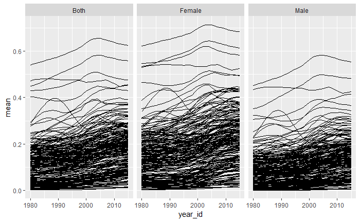

```r
obesity_data %>%
  filter(metric == "Percent") %>%
  filter(age_group_name == "adults (20+) age-standardized`") %>%
  ggplot(aes(x = year_id, y = mean, group = location_name)) +
  geom_line() +
  facet_wrap(~sex)
```

Now to see if I can find the specific OECD countries listed above

First define the countries as a long vector of character strings

```r
countries_to_find <- c(
 "Australia",
 "Austria",
 "Belgium",
 "Canada",
 "Chile",
 "Czech Republic",
 "Denmark",
 "Estonia",
 "Finland",
 "France",
 "Germany",
 "Greece",
 "Hungary",
 "Iceland",
 "Ireland",
 "Israel",
 "Italy",
 "Japan",
 "South Korea",
 "Latvia",
 "Lithuania",
 "Luxembourg",
 "Mexico",
 "Netherlands",
 "New Zealand",
 "Norway",
 "Poland",
 "Portugal",
 "Slovak Republic",
 "Slovenia",
 "Spain",
 "Sweden",
 "Switzerland",
 "Turkey",
 "Scotland",
 "England",
 "Northern Ireland",
 "Wales",
 "United States"
)
```

Now to see if at least one entry picked up for each

```r
obesity_data %>%
  filter(metric == "Percent") %>%
  filter(age_group_name == "adults (20+) age-standardized`") %>%
  filter(sex != "Both") %>%
  filter(location_name %in% countries_to_find) %>%
  ggplot(aes(x = year_id, y = mean, group = location_name, colour = sex)) +
  geom_line() +
  facet_wrap(~location_name)
```

The data provided does not disaggregate the UK into countries.

```r
countries_to_find <- c(
 "Australia",
 "Austria",
 "Belgium",
 "Canada",
 "Chile",
 "Czech Republic",
 "Denmark",
 "Estonia",
 "Finland",
 "France",
 "Germany",
 "Greece",
 "Hungary",
 "Iceland",
 "Ireland",
 "Israel",
 "Italy",
 "Japan",
 "South Korea",
 "Latvia",
 "Lithuania",
 "Luxembourg",
 "Mexico",
 "Netherlands",
 "New Zealand",
 "Norway",
 "Poland",
 "Portugal",
 "Slovak Republic",
 "Slovenia",
 "Spain",
 "Sweden",
 "Switzerland",
 "Turkey",
 "United Kingdom",
 "United States"
)
```

Now to redo the figures

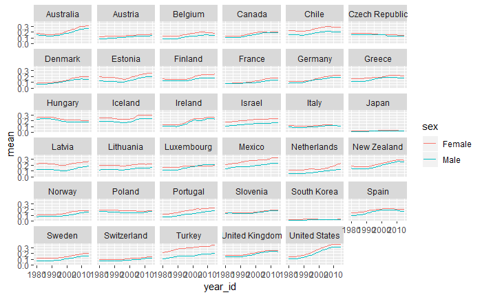

```r
obesity_data %>%
  filter(metric == "Percent") %>%
  filter(age_group_name == "adults (20+) age-standardized`") %>%
  filter(sex != "Both") %>%
  filter(location_name %in% countries_to_find) %>%
  ggplot(aes(x = year_id, y = mean, colour = sex)) +
  geom_line() +
  facet_wrap(~location_name)
```

And now to save the data

| country | sex | year | pct_obese |
| --- | --- | --- | --- |
| Czech Republic | Male | 1980 | 0.16040521 |
| Czech Republic | Female | 1980 | 0.18245714 |
| Czech Republic | Male | 1981 | 0.16080563 |
| Czech Republic | Female | 1981 | 0.18295506 |
| Czech Republic | Male | 1982 | 0.16064209 |
| Czech Republic | Female | 1982 | 0.18287715 |
| Czech Republic | Male | 1983 | 0.16038091 |
| Czech Republic | Female | 1983 | 0.18272771 |
| Czech Republic | Male | 1984 | 0.16008656 |
| Czech Republic | Female | 1984 | 0.18251225 |

[output cut: 990 more lines]

A couple of explorations within countries by age group (not organised into increasing age groups)

Firstly Italy:

```r
obesity_data %>%
  filter(metric == "Percent") %>%
  filter(sex != "Both") %>%
  filter(location_name == "Italy") %>%
  ggplot(aes(x = year_id, y = mean, colour = sex)) +
  geom_line() +
  facet_wrap(~age_group_name)
```

Now the United Kingdom

```r
obesity_data %>%
  filter(metric == "Percent") %>%
  filter(sex != "Both") %>%
  filter(location_name == "United Kingdom") %>%
  ggplot(aes(x = year_id, y = mean, colour = sex)) +
  geom_line() +
  facet_wrap(~age_group_name)
```

And now France

```r
obesity_data %>%
  filter(metric == "Percent") %>%
  filter(sex != "Both") %>%
  filter(location_name == "France") %>%
  ggplot(aes(x = year_id, y = mean, colour = sex)) +
  geom_line() +
  facet_wrap(~age_group_name)
```

Finally, the USA

```r
obesity_data %>%
  filter(metric == "Percent") %>%
  filter(sex != "Both") %>%
  filter(location_name == "United States") %>%
  ggplot(aes(x = year_id, y = mean, colour = sex)) +
  geom_line() +
  facet_wrap(~age_group_name)
```

In the case of the USA, there’s clearly been an ‘obesogenic transition’, from around 10% in the early 1980s to around 35-40% by the mid 2000s. However it’s plateaued.

The finding that, at least in the countries explored, rates of obesity peaked in the mid/late 2000s, whereas the mortality slowdown occurred post 2012ish, intuitively suggests that obesity isn’t a primary explanation for the slowdown. (However, the formal analysis is still to be done)

## Life expectancy

Let’s now move to the e0 data

(I’m not immediately sure which file is males and which is females, but should be able to find out by looking at the data)

```r
e0_male <- read_csv("data/raw/e0/UNdata_Export_20190702_165521202/UNdata_Export_20190702_165521202.csv")
e0_female <- read_csv("data/raw/e0/UNdata_Export_20190702_165541969/UNdata_Export_20190702_165541969.csv")
```

Let’s set up the year column to be easier to work with

```r
e0_combined <- e0_male %>%
  rename(year_range = `Year(s)`) %>%
  separate(year_range, into = c("start_year", "end_year"), sep = "-", convert = TRUE) %>%
  rename(male = Value) %>%
  inner_join(
    e0_female %>%
      rename(year_range = `Year(s)`) %>%
      separate(year_range, into = c("start_year", "end_year"), sep = "-", convert = TRUE) %>%
      rename(female = Value)
  )
```

Now let’s look at the data to work out which life expectancy is likely to correspond to which gender

```r
e0_combined %>%
  gather(key = "sex", value = "e0", male:female) %>%
  filter(`Country or Area` == "United Kingdom") %>%
  ggplot(aes(x = start_year, y = e0, colour = sex, group = sex)) +
  geom_line() +   geom_point() +
  facet_wrap(~`Country or Area`)
```

Now to get mid year, and filter on countries of interest

```r
e0_combined %>%
  gather(key = "sex", value = "e0", male:female) %>%
  mutate(mid_year = start_year + (end_year - start_year)/2) %>%
  filter(mid_year < 2016) %>%
  rename(country = `Country or Area`) %>%
  filter(country %in% countries_to_find) %>%
  ggplot(aes(x = mid_year, y = e0, colour = sex, group = sex)) +
  geom_point() + geom_line() +
  facet_wrap(~country)
```

Missing:

- Czech Republic (Czechia)
- Slovak Republic (Slovakia)
- United States (United States of America)

Let’s find these countries in the UN dataset and rename them so they match

```r
unique(e0_combined$`Country or Area`)
```

So these three need renaming for consistency first

```r
e0_combined %>%
  gather(key = "sex", value = "e0", male:female) %>%
  mutate(mid_year = start_year + (end_year - start_year)/2) %>%
  filter(mid_year < 2016) %>%
  rename(country = `Country or Area`) %>%
  mutate(country = case_when(
    country == "United States of America" ~ "United States",
    country == "Czechia"                  ~ "Czech Republic",
    country == "Slovakia"                 ~ "Slovak Republic",
    TRUE                                  ~ country
    )
  ) %>%
  filter(country %in% countries_to_find) %>%
  ggplot(aes(x = mid_year, y = e0, colour = sex, group = sex)) +
    geom_point() + geom_line() +
    facet_wrap(~country)
```

So all countries are now identified. Let’s save this

```r
e0_tidied <- e0_combined %>%
  gather(key = "sex", value = "e0", male:female) %>%
  mutate(mid_year = start_year + (end_year - start_year)/2) %>%
  filter(mid_year < 2016 & mid_year > 1979) %>%
  rename(country = `Country or Area`) %>%
  mutate(country = case_when(
    country == "United States of America" ~ "United States",
    country == "Czechia"                  ~ "Czech Republic",
    country == "Slovakia"                 ~ "Slovak Republic",
    TRUE                                  ~ country
    )
  ) %>%
  filter(country %in% countries_to_find) %>%
  select(country, start_year, mid_year, end_year, sex, e0)
```

Now to join the data

```r
combined_data <- obesity_data_tidied %>%
  mutate(year_grp = cut(year, seq(1980, 2020, 5), include.lowest = TRUE) %>% as.character()) %>%
  mutate(year_grp = str_replace(year_grp, "\\[", "")) %>%
  mutate(year_grp = str_replace(year_grp, "\\]", "")) %>%
  mutate(year_grp = str_replace(year_grp, "\\(", "")) %>%
  mutate(sex = tolower(sex)) %>%
  separate(year_grp, into = c("start_year", "end_year"), convert = TRUE) %>%
  group_by(country, sex, start_year, end_year) %>%
  summarise(pct_obese = mean(pct_obese)) %>%
  ungroup() %>%
  inner_join(
    e0_tidied
  )
```

We can now show the association in 1980 and in the last common period

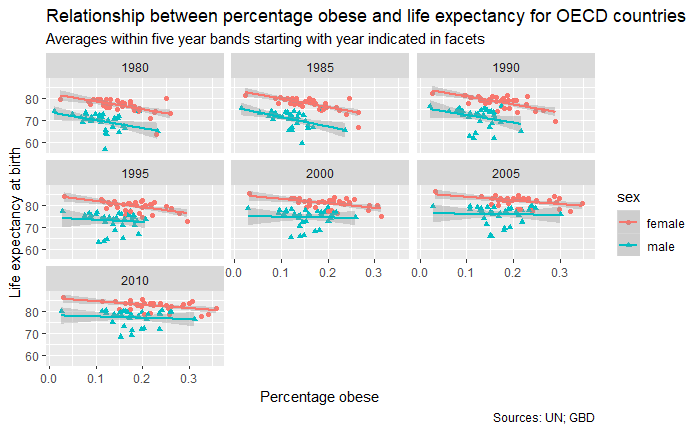

```r
combined_data %>%
  ggplot(aes(x = pct_obese, y = e0, group = sex, colour = sex, shape = sex)) +
  geom_point() +
  facet_wrap(~start_year) +
  stat_smooth(method = "lm") +
  labs(
    x = "Percentage obese",
    y = "Life expectancy at birth",
    title = "Relationship between percentage obese and life expectancy for OECD countries",
    subtitle = "Averages within five year bands starting with year indicated in facets",
    caption = "Sources: UN; GBD"
  )
ggsave("figures/scatterplot.png", height = 20, width = 25, units = "cm", dpi = 300)
```